# The Culture of Silence surrounding Rape: Evidence from New York

Yu Chen, Matt Dwyer, Davey Ives, Konstantin Klemmer, Rachel Lim, Sunglyoung Kim

June 12, 2017

# Introduction

In 2015, the New York City Police Department released its incident reports for felonies, following a greater citywide trend of data transparency. The data released details the location, time, date, and day of occurrence, time and date of reported, sector, precinct, borough, jurisdiction and type of felony that reported in 2015 across the city. The seven felonies in the dataset correspond with the FBI’s seven major felonies, which cover murder, rape, robbery, assault, burglary, grand larceny, and grand larceny of motor vehicles. Through the release of NYPD’s crime data, this study aims to investigate the spatial and temporal spread of crimes across NYC, along with the difference between crime occurrence and when the crime was reported. By employing statistical and mapping methods, the data can answer high level questions about what time of day or day of the week see increased criminal activity, how specific types of felonies cluster across the city, and how crime reporting times vary between felonies.

```
##                                Total Crimes  Percentage
## BURGLARY                              10945 0.142596574
## FELONY ASSAULT                        15056 0.196156602
## GRAND LARCENY                         31655 0.412416129
## GRAND LARCENY OF MOTOR VEHICLE         5515 0.071851997
## MURDER                                  257 0.003348316
## RAPE                                   1080 0.014070745
## ROBBERY                               12247 0.159559638
```

Table 1: Distribution of offenses across all crime

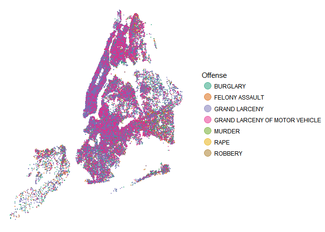

Figure 1: Mapping crime by offense

# Data and Methods

The data provided by the NYPD reflected simple digital coordinates. For the initial data exploration, location granularity was narrowed to the census tract level instead of zip code level to improve the level of accuracy. This level of accuracy allows location specific characteristics that may be left out on the zip code level to be identified. Using this level of location granularity, the spatial spread of crime counts across the city for each respective felony can be computed. Out of these 7 felonies, the number of reported assault and robbery incidents are mapped out by census tract. In Figure 2, the highest number of assaults is observed on Rikers Island, which houses New York City’s main jail complex.

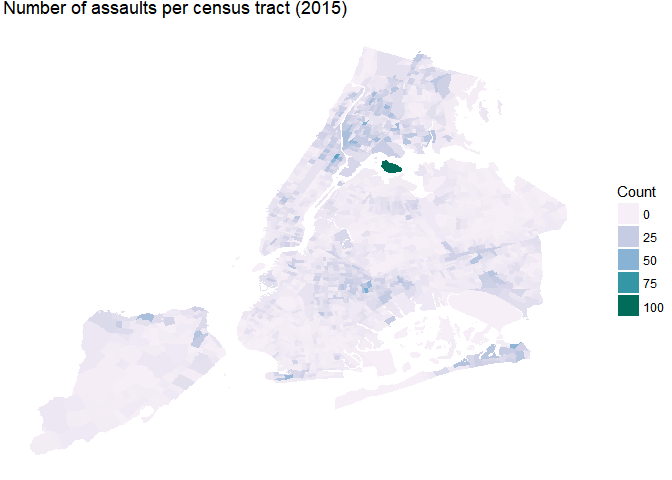

Figure 2: Assault counts (2015) across census tracts

Figure 3 shows the number of robberies per census tract, with areas such as Flatbush and Harlem observing high numbers of robberies.

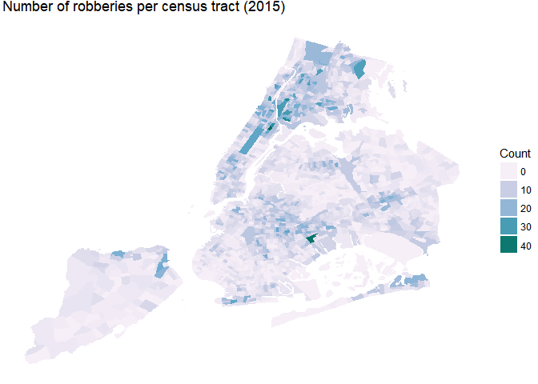

Figure 3: Robbery counts (2015) across census tracts

Apart from understanding the distribution of crime across space, the temporal component of the data is equally crucial to our research. The distribution of crime occurrence over the course of a week and a day are shown in Figure 4.

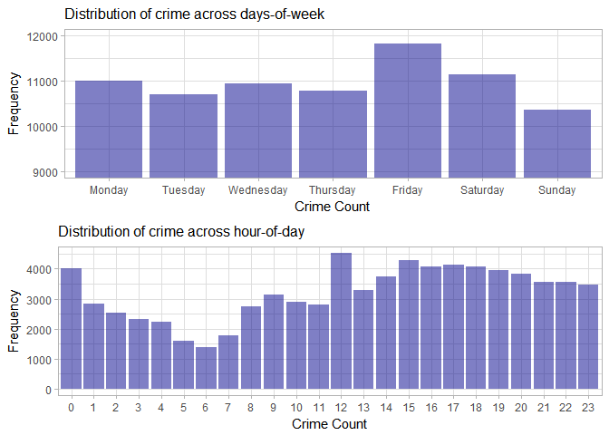

Figure 4: Temporal distribution of criminal activity

This reflects the peaks and troughs in crime incidents across New York, but is limited in providing deeper insight. A more crucial aspect of the temporal dimension of the data is the time difference between the occurrence time of the felony and the actual time which it was reported to the police (Figure 5).

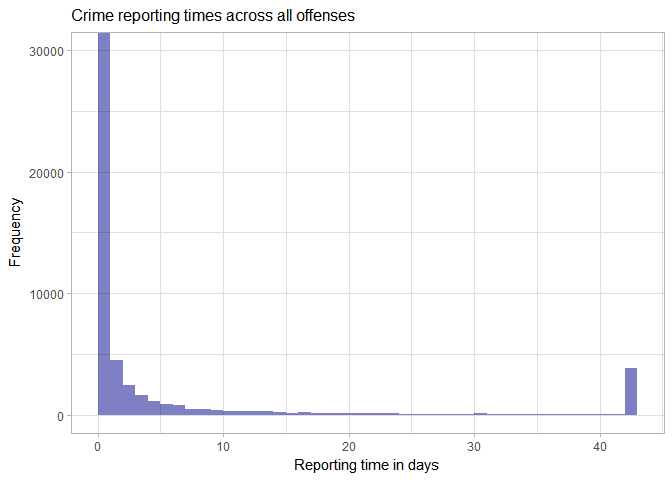

Figure 5: Histogram of reporting times for all crimes (2015)

The median time gap is computed with high values fixed to the 95% quantile to reduce the effect of heavy outliers in the data, providing a more accurate representation of the difference. The figure indicates that while majority of crime incidents are reported within a short time frame of 0 to 5 days, a significant number of crime incidents are reported after an extended period of time. To better understand the factors contributing to the long time gap, the mean, median and standard deviation for each felony is computed (Table 2).

```
##                          Offense       Mean Median Std.Deviation
## 1                         MURDER  1.5564202      0      7.945968
## 2                           RAPE 15.0342593      2     18.679228
## 3                        ROBBERY  0.8957296      0      4.062209
## 4                 FELONY ASSAULT  1.4266738      0      5.604116
## 5                       BURGLARY  2.4848789      1      6.733721
## 6                  GRAND LARCENY  8.0393619      1     13.687406
## 7 GRAND LARCENY OF MOTOR VEHICLE  2.6297371      1      6.501638
## 8                          TOTAL  4.4983780      1     10.591798
```

Table 2: Descriptive statistics for reporting times across different offense types

# Discussion

## Reporting Time Delays

One of our key findings what that the largest differences in reporting time occurred between the seven felony types. Below are possible explanations for why these differences occur.

## Rape

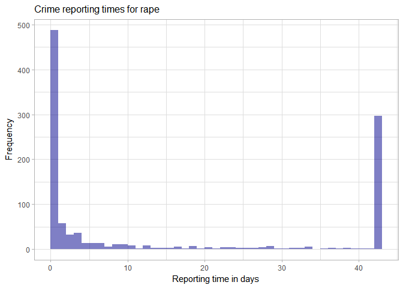

Figure 6: Reporting times for rape

This draws our attention to the reasons for delaying reporting a crime following the incident. This is contingent on a number of factors. Existing research have looked into why victims don’t report rape crimes to the authorities. Courtney Aherns discusses this in her paper “Being Silenced: The Impact of Negative Social Reactions on the Disclosure of Rape.”. This is supported by Kilpatrick, Dean G., et al. in “Criminal Victimization: Lifetime Prevalence, Reporting to Police, and Psychological Impact.”. However, there remains a gap in the research in understanding more in depth reasons for delaying reporting a crime. This includes the need for a better understanding of the psychological and physical effects of rape on the victim, to better explain the 30 days after the crime.

Connecting the spatial and temporal perspective, we can identify areas that show both, a high number of rapes as well as a high mean reporting time. While spatial coordinates for rape are only reported on a precinct level, this still allows us to identify especially bad precincts (see Figure 7). Our findings may help in planning and coordinating policy interventions to tackle rape. Furthermore, we hope to raise awareness for an often surpressed issue by showing where rape is especially prevalent and where reporting times are especially long.

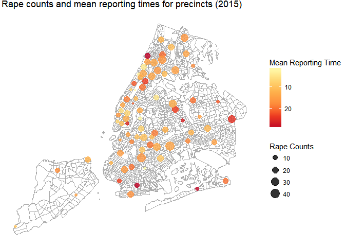

# Limitations and Further Research

While the report has successfully revealed the long time gap between occurrence date and reporting date for specific felonies such as rape, more research needs to be conducted to better understand the reasons behind this time lag. The report has proposed some general reasons, but effective response to the problem will require more specific information on the age groups of victims, and background knowledge of the perpetrator.

The research on rape incidents in the city is limited by the nature of the data available. As discussed above, coordinates for rape incidents were masked and listed on the precinct level rather than the exact latitude/longitude coordinates to maintain confidentiality of the data. As a result, geospatial mapping of rape crime across the city appears scattered. In addition, the outliers in the data set may skew the data set, for instance, a murder that occurred in 1982 was only reported in 2015. While these outliers have been taken care of in the report, it may nevertheless affect the accuracy of our research.

Nevertheless, the report has wider implications in drawing attention to the long time gap in reporting rape incidents, particularly in states with statutes of limitations on filing rape charges. 34 states have statutes of limitations, preventing victims who delay reporting the crime from pressing charges. The data presented in this report exemplifies the long ‘culture of silence’ on rape, suggesting that more education and support networks needs to be in place to eradicate social stigma surrounding rape. Our research is also limited by the fact that a significant portion of rape incidents often go unreported, with RAINN estimating that only 32 percent of rapes are reported.

# Conclusion

To conclude, the report has presented evidence supporting the ‘culture of silence’ surrounding rape. It has also highlighted key areas in the city where more efforts in education and support can be improved. Overall the trends observed in all felonies can also inform and improve policing in the city.

# References

Ahrens, Courtney E. “Being Silenced: The Impact of Negative Social Reactions on the Disclosure of Rape.” American Journal of Community Psychology , vol. 38, no. 3-4, Sept. 2006, pp. 31-34., doi:10.1007/s10464-006-9069-9.

Bachman, Ronet. “Predicting the Reporting of Rape Victimizations.” Criminal Justice and Behavior , vol. 20, no. 3, 1993, pp. 254-270., doi:10.1177/0093854893020003003.

New York City Police Department “Historical New York City Crime Data.”, 30 Dec. 2015.

Kilpatrick, Dean G., et al. “Criminal Victimization: Lifetime Prevalence, Reporting to Police, and Psychological Impact.” Crime & Delinquency , vol. 33, no. 4, 1987, pp. 479-489., doi:10.1177/0011128787033004005.